# Portfolio Assessment: Performance and selling strategies

2020-09-14

A timely retreat is a victory.

### Our portfolio`

Portfolio

| Ticker | nShares | AP | CP | CV | weight |
| --- | --- | --- | --- | --- | --- |
| VOW3.DE | 50 | 93.0 | 148.420 | 7421.0 | 0.2133648 |
| PUM.DE | 80 | 55.4 | 74.440 | 5955.2 | 0.1712209 |
| MC.PA | 14 | 350.0 | 420.250 | 5883.5 | 0.1691594 |
| DGV.MI | 165 | 30.5 | 31.500 | 5197.5 | 0.1494359 |
| CS.PA | 300 | 16.1 | 17.272 | 5181.6 | 0.1489787 |
| UNA.AS | 100 | 46.0 | 51.420 | 5142.0 | 0.1478402 |

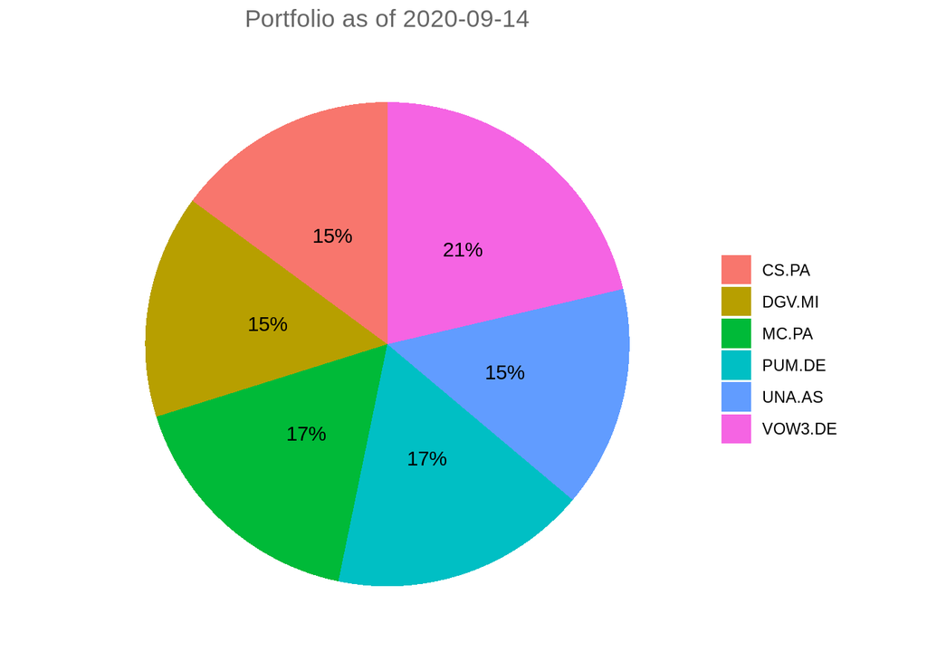

### Factor 1: Quality

1. Healthy debts: A company shoud generate cash in order to repay its debt. The **Free Cash Flow to Debt** ratio is a good indicator of how quick a company pays back its debt. The lower this ratio the better.

FCF2D = $\frac{Debt}{Free Cash Flow}$

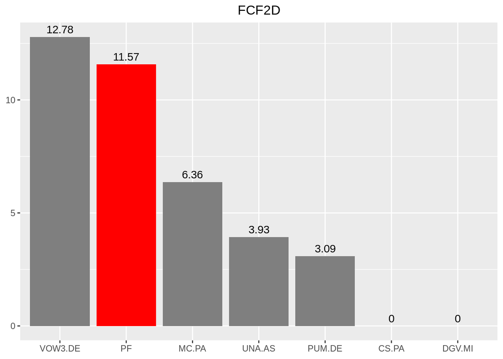

2. Profitability: ROA

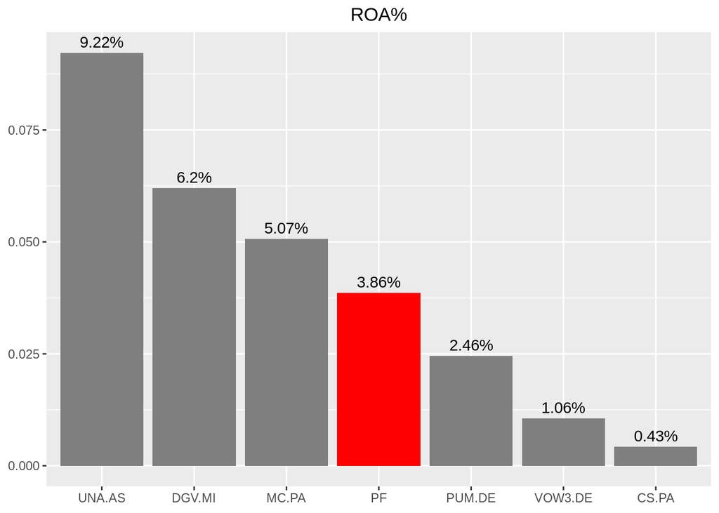

3. High Margin: We look for companies that generate free cash flow compare to its price. The **Free Cash Flow to Entreprise Value** ratio tells us how many years of cash flow would be needed to the return the 100% of the investment. Again, the lower, the better. Values bellow 1 would mean "free lunch".

FCF2EV = $\frac{EV}{Free Cash Flow}$

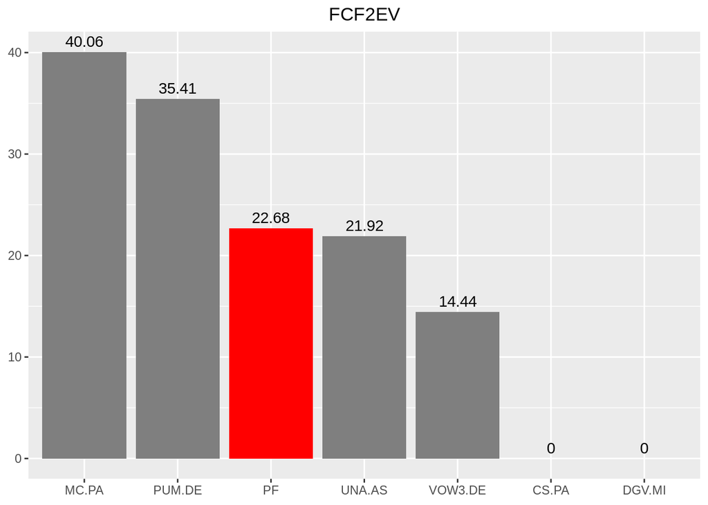

### Factor 2: Momentum

Don't hold onto a stock simply because it is high quality. So called quality stocks have cycles too. Stan Weinstein (page 177)

Generic Intermediate-Term Momentum Based on Gray-Vogel (page 80)

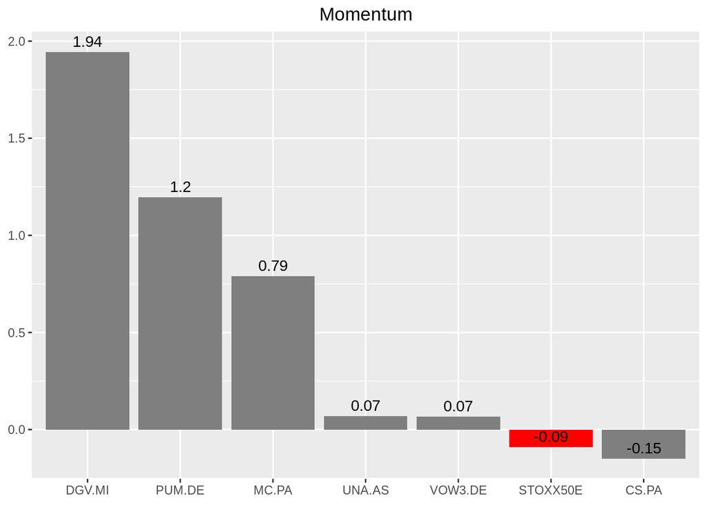

### Factor 3: Timing Signal

Sell Signal - Pr < 1% SMA 30 weeks and slope negative (< 0.1) Hold Signal - No Sell

**StopLoss for the next month**

Every month, we calculate a generic the StopLoss given a "Loss Threshold"" of 15% and "ProfitDropThreshold" of 20%. In addition, there's an accurate StopLoss for those stocks with "hold" signal, of 5% of their MA.

### Summary

Summary

| Ticker | AP | CP | weight | StopLossFinal | Signal | Quality | Momentum | Final_rank |
| --- | --- | --- | --- | --- | --- | --- | --- | --- |
| DGV.MI | 30.5 | 31.500 | 0.1494 | 26.23 | HOLD | 6.0 | 6 | 6.0 |
| PUM.DE | 55.4 | 74.440 | 0.1712 | 60.08 | HOLD | 3.0 | 5 | 5.0 |
| UNA.AS | 46.0 | 51.420 | 0.1478 | 44.47 | HOLD | 4.5 | 3 | 4.0 |
| MC.PA | 350.0 | 420.250 | 0.1692 | 350.14 | HOLD | 1.5 | 4 | 2.5 |
| CS.PA | 16.1 | 17.272 | 0.1490 | 15.39 | HOLD | 4.5 | 1 | 2.5 |
| VOW3.DE | 93.0 | 148.420 | 0.2134 | 125.23 | HOLD | 1.5 | 2 | 1.0 |